# Ms Draft: The biodiversity of plant-frugivore interactions: types, functions, and consequences

Pedro Jordano

true

2025-01-21

Abstract

Pairwise plant-frugivore mutualistic interactions build up into mega-diverse networks involving dozens of interacting species, being the most generalized among free-living species. These mutualisms consist of food provisioning by plants and, their counterpart, plant propagule (seeds) movement by the animals, being crucial for the natural vegetation regeneration in many ecosystems. Yet we are far from understanding which part of this enormous interaction biodiversity is needed for their maintenance. I overview the diversity of interaction modes involved in these mutualisms, the main components of the seed dispersal services, and their functional diversity. I examine how interaction richness covaries with partner species richness at different scales, resulting in variable patterns of species complementarities in terms of seed dispersal effects. The functionality of most generalized plant-frugivore mutualisms relies on complementarity of effects across a high diversity of partners, yet frequently depends on just a distinct subset of them, resulting in high functional redundancy. Two distinct aspects are relevant: 1) variable quantitative effects among species; 2) variable parwise-interaction outcomes, between the extremes of antagonism and mutualism.

{{< pagebreak >}}

### Interaction richness and diversity

```r
# here()
mypath<- here(c("data/data.tsv"))
data1 <- read.csv(mypath, sep="\t", dec=",", header=T,
                  comment.char = "#")
# data <- data %>%
#            arrange(sp_plant, desc(pct_mut))
```

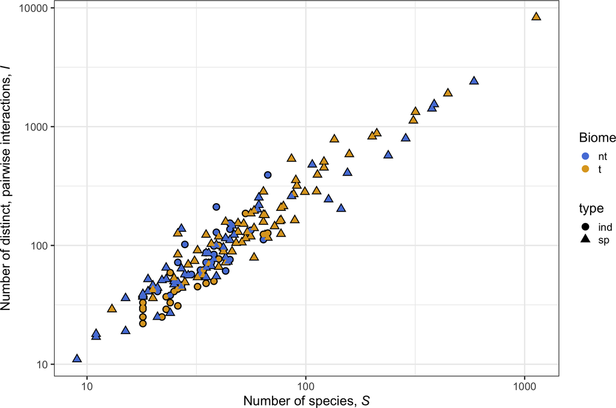

```r
# here()
# Scatter plot
theme_set(theme_bw(base_size = 18))
p1<- ggplot(data1, aes(x= S, y= I, color=biome, shape= type)) +
            geom_point(size= 4) +
            geom_point(aes(color= biome), size= 4.5, color= "black") +
#           geom_point(aes(color= biome), size= 5) +
            geom_point(aes(color= biome), size= 3) +
            scale_x_continuous(trans='log10') +
            scale_y_continuous(trans='log10') +
            scale_color_manual(values=c("#5681DC", "#DEA525")) +
            ggplot2::labs(color = "Biome") +
            ggplot2::labs(x = TeX(r"(Number of species, \textit{S})"),
                y = TeX(r"(Number of distinct, pairwise interactions, \textit{I})"))
p1
```

#### Model fit, pooled data

```r
m1 <- lm(I ~ S, data = data1)
equatiomatic::extract_eq(m1)
```

$$\operatorname{I} = \alpha + \beta_{1}(\operatorname{S}) + \epsilon$$

```r
equatiomatic::extract_eq(m1, use_coefs = TRUE)
```

$$\operatorname{\widehat{I}} = -168.34 + 5.87(\operatorname{S})$$

```r
summary(m1)
```

```
Call:
lm(formula = I ~ S, data = data1)

Residuals:
   Min     1Q Median     3Q    Max
-880.2  -25.8   34.6   73.8 1853.6

Coefficients:
            Estimate Std. Error t value Pr(>|t|)
(Intercept) -168.338     19.995   -8.42  1.8e-14 ***
S              5.871      0.149   39.30  < 2e-16 ***
---
Signif. codes:  0 '***' 0.001 '**' 0.01 '*' 0.05 '.' 0.1 ' ' 1

Residual standard error: 221 on 165 degrees of freedom
Multiple R-squared:  0.904, Adjusted R-squared:  0.903
F-statistic: 1.54e+03 on 1 and 165 DF,  p-value: <2e-16
```

```r
parameters::parameters(m1)
```

```
Parameter   | Coefficient |    SE |             95% CI | t(165) |      p
------------------------------------------------------------------------
(Intercept) |     -168.34 | 20.00 | [-207.82, -128.86] |  -8.42 | < .001
S           |        5.87 |  0.15 | [   5.58,    6.17] |  39.30 | < .001
```

```r
# Separate effects of Animal and Plant species richness on I.
m2 <- lm(I ~ P+A, data = data1)
equatiomatic::extract_eq(m2)
```

$$\operatorname{I} = \alpha + \beta_{1}(\operatorname{P}) +
\beta_{2}(\operatorname{A}) + \epsilon$$

```r
equatiomatic::extract_eq(m2, use_coefs = TRUE)
```

$$\operatorname{\widehat{I}} = -121.8 + 8.06(\operatorname{P}) +
1.47(\operatorname{A})$$

```r
summary(m2)
```

```
Call:
lm(formula = I ~ P + A, data = data1)

Residuals:
   Min     1Q Median     3Q    Max
-724.4  -27.9   35.2   80.8 1589.8

Coefficients:
            Estimate Std. Error t value Pr(>|t|)
(Intercept) -121.801     20.785   -5.86  2.5e-08 ***
P              8.064      0.456   17.69  < 2e-16 ***
A              1.474      0.882    1.67    0.096 .
---
Signif. codes:  0 '***' 0.001 '**' 0.01 '*' 0.05 '.' 0.1 ' ' 1

Residual standard error: 206 on 164 degrees of freedom
Multiple R-squared:  0.917, Adjusted R-squared:  0.916
F-statistic:  900 on 2 and 164 DF,  p-value: <2e-16
```

```r
parameters::parameters(m2)
```

```
Parameter   | Coefficient |    SE |            95% CI | t(164) |      p
-----------------------------------------------------------------------
(Intercept) |     -121.80 | 20.78 | [-162.84, -80.76] |  -5.86 | < .001
P           |        8.06 |  0.46 | [   7.16,   8.96] |  17.69 | < .001
A           |        1.47 |  0.88 | [  -0.27,   3.21] |   1.67 | 0.096
```

#### Summary stats, by biome

```r
library(rstatix)
# summary statistics for dependent variable yield
ppp<- data1 %>% dplyr::group_by(biome) %>% get_summary_stats(c(A,P,S,I,C), type="common")
ppp_srt<- ppp %>%
            arrange(variable, biome)
kable(ppp_srt)
```

| biome | variable | n | min | max | median | iqr | mean | sd | se | ci |
| --- | --- | --- | --- | --- | --- | --- | --- | --- | --- | --- |
| nt | A | 76 | 6.000 | 226.000 | 15.500 | 17.500 | 28.263 | 37.389 | 4.289 | 8.544 |
| t | A | 91 | 5.000 | 343.000 | 20.000 | 31.000 | 31.758 | 42.327 | 4.437 | 8.815 |
| nt | P | 76 | 3.000 | 361.000 | 15.500 | 21.000 | 33.329 | 57.261 | 6.568 | 13.085 |
| t | P | 91 | 5.000 | 787.000 | 24.000 | 21.000 | 44.429 | 91.060 | 9.546 | 18.964 |
| nt | S | 76 | 9.000 | 587.000 | 35.500 | 21.250 | 61.592 | 93.116 | 10.681 | 21.278 |
| t | S | 91 | 13.000 | 1130.000 | 46.000 | 46.500 | 76.253 | 130.145 | 13.643 | 27.104 |
| nt | I | 76 | 11.000 | 2398.000 | 72.500 | 87.500 | 182.605 | 362.648 | 41.599 | 82.869 |
| t | I | 91 | 22.000 | 8320.000 | 115.000 | 132.000 | 288.308 | 900.564 | 94.405 | 187.551 |
| nt | C | 76 | 0.029 | 0.852 | 0.314 | 0.192 | 0.332 | 0.167 | 0.019 | 0.038 |
| t | C | 91 | 0.031 | 0.787 | 0.228 | 0.206 | 0.267 | 0.156 | 0.016 | 0.033 |

```r
# Separate regressions for biomes
#
# Tropical
ppp<- data1 %>% dplyr::filter(biome== "t")
m2<- lm(I ~ S, data = ppp)
equatiomatic::extract_eq(m2)
```

$$\operatorname{I} = \alpha + \beta_{1}(\operatorname{S}) + \epsilon$$

```r
equatiomatic::extract_eq(m2, use_coefs = TRUE)
```

$$\operatorname{\widehat{I}} = -226.09 + 6.75(\operatorname{S})$$

```r
summary(m2)
```

```
Call:
lm(formula = I ~ S, data = ppp)

Residuals:
   Min     1Q Median     3Q    Max
-880.6  -82.4   35.8   97.8  923.2

Coefficients:
            Estimate Std. Error t value Pr(>|t|)
(Intercept) -226.087     24.537   -9.21  1.4e-14 ***
S              6.746      0.163   41.30  < 2e-16 ***
---
Signif. codes:  0 '***' 0.001 '**' 0.01 '*' 0.05 '.' 0.1 ' ' 1

Residual standard error: 202 on 89 degrees of freedom
Multiple R-squared:  0.95,  Adjusted R-squared:  0.95
F-statistic: 1.71e+03 on 1 and 89 DF,  p-value: <2e-16
```

```r
parameters::parameters(m2)
```

```
Parameter   | Coefficient |    SE |             95% CI | t(89) |      p
-----------------------------------------------------------------------
(Intercept) |     -226.09 | 24.54 | [-274.84, -177.33] | -9.21 | < .001
S           |        6.75 |  0.16 | [   6.42,    7.07] | 41.30 | < .001
```

```r
# Non-tropical
ppp<- data1 %>% dplyr::filter(biome== "nt")
m3 <- lm(I ~ S, data = ppp)
equatiomatic::extract_eq(m3)
```

$$\operatorname{I} = \alpha + \beta_{1}(\operatorname{S}) + \epsilon$$

```r
equatiomatic::extract_eq(m3, use_coefs = TRUE)
```

$$\operatorname{\widehat{I}} = -51.65 + 3.8(\operatorname{S})$$

```r
summary(m3)
```

```
Call:
lm(formula = I ~ S, data = ppp)

Residuals:
    Min      1Q  Median      3Q     Max
-296.83  -13.33    5.03   25.27  217.12

Coefficients:
            Estimate Std. Error t value Pr(>|t|)
(Intercept) -51.6470    10.8290   -4.77    9e-06 ***
S             3.8033     0.0974   39.03   <2e-16 ***
---
Signif. codes:  0 '***' 0.001 '**' 0.01 '*' 0.05 '.' 0.1 ' ' 1

Residual standard error: 78.6 on 74 degrees of freedom
Multiple R-squared:  0.954, Adjusted R-squared:  0.953
F-statistic: 1.52e+03 on 1 and 74 DF,  p-value: <2e-16
```

```r
parameters::parameters(m3)[1,]
```

```
Parameter   | Coefficient |    SE |           95% CI | t(74) |      p
---------------------------------------------------------------------
(Intercept) |      -51.65 | 10.83 | [-73.22, -30.07] | -4.77 | < .001
```

#### ANCOVA test

```r
kable(anova_test(data = data1, formula = I ~ S + biome, type = 3, detailed = TRUE))
```

| Effect | SSn | SSd | DFn | DFd | F | p | p<.05 | ges |
| --- | --- | --- | --- | --- | --- | --- | --- | --- |
| (Intercept) | 3467595 | 8023961 | 1 | 164 | 70.873 | 0.000 | * | 0.302 |
| S | 74830909 | 8023961 | 1 | 164 | 1529.453 | 0.000 | * | 0.903 |
| biome | 16012 | 8023961 | 1 | 164 | 0.327 | 0.568 |  | 0.002 |

```r
# Type 3 SS should be used in ANCOVA
kable(Anova(aov(I ~ biome * S, data = data1), type = 3))
```

|  | Sum Sq | Df | F value | Pr(>F) |
| --- | --- | --- | --- | --- |
| (Intercept) | 140453 | 1 | 5.6156 | 0.01897 |
| biome | 900414 | 1 | 36.0007 | 0.00000 |
| S | 9406573 | 1 | 376.0974 | 0.00000 |
| biome:S | 3947167 | 1 | 157.8172 | 0.00000 |
| Residuals | 4076794 | 163 | NA | NA |

### Interaction richness and functional traits

Here I examine the functional characteristics of frugivore asemblages using two species, *Prunus mahaleb* [@Jordano.Schupp:2000] and *Euterpe edulis* [@Galetti.etal:2013:S]. First, I examine how variation in functional traits of frugivore species and the resulting interaction effectiveness generate gradients of interaction outcomes ranging from purely mutualistic to purely antagonistic effects on fitness. Second, I show how the functional diversity increases as the species richness of the frugivore assemblage increases.

Additional data for functional traits come from @Jordano.ea:2025:Ard, @Bovo.Ferraz.ea:2018, and @Galetti.etal:2013:S.

## The distribution of functional interaction outcomes

Here I show the frequency distributions of mutualistic outcomes for the two species. Individual frugivore species are ranked from those with 100% mutualistic interaction outcomes (no fruits dropped or seeds damaged during foraging) to those with purely antagonistic outcomes (100% of the feeding sequences ending in fruit dropping and/or seed predation).

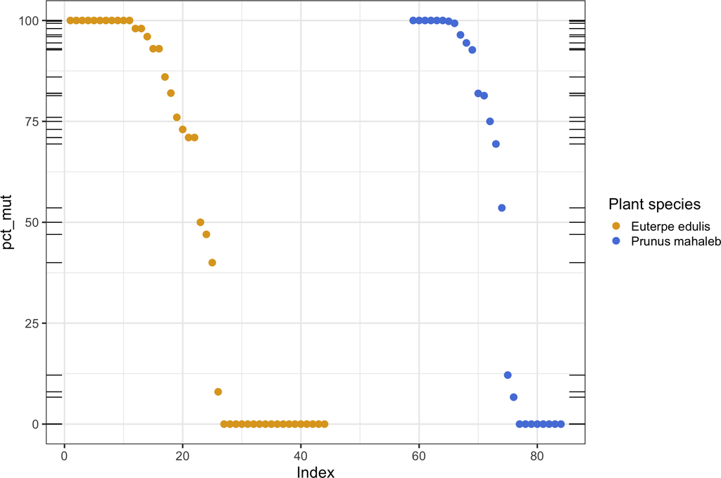

```r
# here()
mypath<- here(c("data/frug-mut_gradient.tsv"))
data2 <- read.csv(mypath, sep="\t", dec=",", header=T,
                  comment.char = "#")

data2 <- data2 %>%
             arrange(sp_plant, desc(pct_mut))

theme_set(theme_bw(base_size = 18))
p <- ggplot(data2, aes(x = 1:nrow(data2), y = pct_mut,
                      color = sp_plant)) +
            geom_point(size=3.5) +
            labs(color = "Plant species") +
            scale_color_manual(values=c("#DEA525","#5681DC")) +
            labs(x = "Index")

p + geom_rug(sides = "rl", color = "black")
```

## Functional diversity as a function of assemblage species richness

For the two species, I include data on frugivore trait variation, local abundance, visitation frequency to the trees, percent contribution to seed dispersal, measures of the quantitative component of seedc dipersal effectiveness `SDE` (effectiveness per visit, visit frequency, and total effectiveness) and species-specific contribution to FD of the assemblage.

```r
# Input functional datasets.
# here()
#---------------------------------------------------------------------
## Euterpe edulis
mypath<- here(c("data/funct.csv"))
funct<- read.csv(mypath, sep=",", dec=".", header=T,
                  comment.char = "#")
funct_euterpe<- funct %>%
                    dplyr::filter(plant == 'Euterpe_edulis')  %>%
                    dplyr::select(species,frug:prop_disp_service)
m_e<- as.matrix(funct_euterpe[,2:7])
sp.names<- funct_euterpe[,1]
rownames(m_e)<- sp.names

a_e<- funct %>%               # Visitation (abund.)
            dplyr::filter(plant == 'Euterpe_edulis')  %>%
            dplyr::select(species,birds.km)
a_e<- t(a_e[,2])
colnames(a_e)<- sp.names

# Observed FD indices.
FDcomp_e <- functcomp(m_e, a_e)
ex_e<-dbFD(m_e, a_e, w.abun=TRUE, calc.FRic=TRUE, calc.FDiv= TRUE,
           corr= "cailliez", messages= TRUE)
```

```
FRic: No dimensionality reduction was required. All 6 PCoA axes were kept as 'traits'.
```

```r
#---------------------------------------------------------------------
# Prunus mahaleb
mypath<- here(c("data/funct.csv"))
funct <- read.csv(mypath, sep=",", dec=".", header=T,
                  comment.char = "#")
funct_prunus<- funct %>%
                    dplyr::filter(plant == 'Prunus_mahaleb')  %>%
                    dplyr::select(species,frug:prop_disp_service)
m_p<-as.matrix(funct_prunus[,2:7])
sp.names<- funct_prunus[,1]

rownames(m_p)<- sp.names

a_p<- funct %>%               # Visitation (abund.)
            dplyr::filter(plant == 'Prunus_mahaleb')  %>%
            dplyr::select(species,birds.km)
sp.names<- a_p[,1]
a_p<- t(a_p[,2])
colnames(a_p)<- sp.names

# Observed FD indices.
FDcomp_p <- functcomp(m_p, a_p)
ex_p<- dbFD(m_p, a_p, w.abun=TRUE, calc.FRic=TRUE, calc.FDiv= TRUE,
           corr= "cailliez", messages = TRUE)
```

```
FRic: No dimensionality reduction was required. All 6 PCoA axes were kept as 'traits'.
```

Here I create simulated assemblages of increasing species richness, between 5 species and the total species number in each assemblage. For each species richness value I get the mean and 1se values for the `FD` indexes. Each assemblage of 5, 6, 7, … $S$ species is generated by bootstrapping (without replacement) the original trait-data matrix.

### Bootstrap `FD` indices-*Euterpe edulis*

```r
# Install and load the boot package
library(boot)

# Create datasets of increasing no. species.
# Create a list to hold the samples.
# This gets as many samples as species, in 1 sp steps. With
# replacement. Loop this for N= 1000.
#
# This filters the abundance dataset so that the species included
# in the abund data are the same as those in the morpho-boot data.
# Filter rows in a_e where species matches any species name in the
# boot-sample.

ta_e<- as.data.frame(t(a_e)) # Transposed abundance data to get
                           # the spp names.
colnames(ta_e)<- c("abund")

# Initialize an empty data frame
dfe <- data.frame(run= integer(), i= integer(),
                  FRic = numeric(), FEve = numeric(),
                  FDis = numeric(),
                  RaoQ = numeric(), FDiv = numeric())
for (run in 1:10) {
    # Loop to create assemblages along a sequence of increasing
    # species richness. From 3 spp to the actual species richness
    # in the assemblage.
    for (i in 5:dim(m_p)[1]) {
        boot_sample<- lapply(1:dim(m_e)[1], function(i) {
        m_e[sample(nrow(m_e), i, replace = FALSE), ] })
    }
    # For each richness value, estimate FD indices.
    for (i in 5:dim(m_p)[1])   {
            thesample= boot_sample[[i]]
            thesample.srt <- thesample[order(rownames(thesample)), ]
            filtered_a_e <- ta_e %>%     # Filtered abundances
                dplyr::filter(row.names(ta_e) %in%
                                row.names(boot_sample[[i]]))
            filtered_a_e.srt<-
                t(filtered_a_e[order(rownames(filtered_a_e)), ])
            colnames(filtered_a_e.srt)<-
                row.names(thesample.srt)
            z<- dbFD(thesample.srt, filtered_a_e.srt,
                     w.abun=TRUE, calc.FRic=TRUE,
                     calc.FDiv= TRUE, corr= "cailliez", messages = FALSE)
     # Append indeces values for i and runs.
            dfe <- rbind(dfe,c(run,i,z$FRic,z$FEve,z$FDis,z$RaoQ,z$FDiv))
    }
}
    colnames(dfe)<- c("run","i","FRic","FEve","FDis","RaoQ","FDiv")

#---------------------------------------------------------------------
# Calculate mean FD values scored by no. species, ignoring NA values
mean_by_no.sp_e <- dfe %>%
  dplyr::group_by(i) %>%
  dplyr::summarise(
    m_FRic= mean(FRic, na.rm = TRUE),
    se_FRic= sd(FRic, na.rm = TRUE) / sqrt(n()),
    m_FEve= mean(FEve, na.rm = TRUE),
    se_FEve= sd(FEve, na.rm = TRUE) / sqrt(n()),
    m_FDis= mean(FDis, na.rm = TRUE),
    se_FDis= sd(FDis, na.rm = TRUE) / sqrt(n()),
    m_RaoQ= mean(RaoQ, na.rm = TRUE),
    se_RaoQ= sd(RaoQ, na.rm = TRUE) / sqrt(n()),
    m_FDiv= mean(FDiv, na.rm = TRUE),
    se_FDiv= sd(FDiv, na.rm = TRUE) / sqrt(n())
  )
#-------------------------------------------------------------------
# FRic
theme_set(theme_bw(base_size = 14))
p1<- ggplot(mean_by_no.sp_e, aes(x = i, y = m_FRic)) +
    geom_smooth(method = "loess", se = TRUE,
            alpha= 0.3, color= "steelblue", fill = "#757171") +
    geom_point(color = "black", fill = "#DEA525", size=3, shape = 21, stroke = 0.5) +
    labs(title = "Euterpe edulis FRic",
                x = "No. species",
                y = "Functional richness (FRic)")
# FDis
theme_set(theme_bw(base_size = 14))
p2<- ggplot(mean_by_no.sp_e, aes(x = i, y = m_FDis)) +
    geom_smooth(method = "loess", se = TRUE,
            alpha= 0.3, color= "steelblue", fill = "#757171") +
    geom_point(color = "black", fill = "#DEA525", size=3, shape = 21, stroke = 0.5) +
    labs(title = "Euterpe edulis FDis",
                x = "No. species",
                y = "Functional dispersion (FDis)")

# grid.arrange(p1, p2, ncol= 2)
```

### Bootstrap `FD` indices-*Prunus mahaleb*

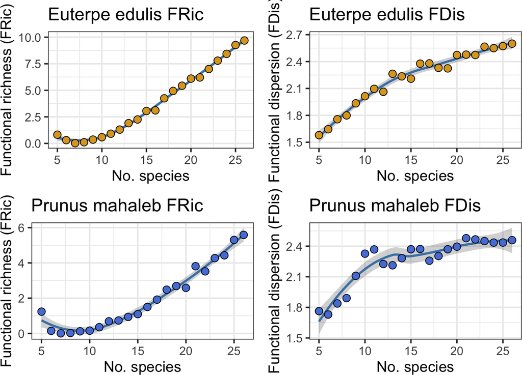

```r
# Install and load the boot package
library(boot)

# Create datasets of increasing no. species.
# Create a list to hold the samples.
# This gets as many samples as species, in 1 sp steps. With
# replacement. Loop this for N= 1000.
#
# This filters the abundance dataset so that the species included
# in the abund data are the same as those in the morpho-boot data.
# Filter rows in a_e where species matches any species name in the
# boot-sample.

ta_p<- as.data.frame(t(a_p)) # Transposed abundance data to get
                             # the spp names.
colnames(ta_p)<- c("abund")

# Initialize an empty data frame
dfp <- data.frame(run= integer(), i= integer(),
                  FRic = numeric(), FEve = numeric(),
                  FDis = numeric(),
                  RaoQ = numeric(), FDiv = numeric())
for (run in 1:10) {
    # Loop to create assemblages along a sequence of increasing
    # species richness. From 3 spp to the actual species richness
    # in the assemblage.
    for (i in 5:dim(m_p)[1]) {
        boot_sample<- lapply(1:dim(m_p)[1], function(i) {
        m_p[sample(nrow(m_p), i, replace = FALSE), ] })
    #}
    # For each richness value, estimate FD indices.
    #   for (i in 3:dim(m_p)[1]   {
            thesample= boot_sample[[i]]
            thesample.srt <- thesample[order(rownames(thesample)), ]
            filtered_a_p <- ta_p %>%     # Filtered abundances
                dplyr::filter(row.names(ta_p) %in%
                                row.names(boot_sample[[i]]))
            filtered_a_p.srt<-
                t(filtered_a_p[order(rownames(filtered_a_p)), ])
            colnames(filtered_a_p.srt)<-
                row.names(thesample.srt)
            z<- dbFD(thesample.srt, filtered_a_p.srt,
                     w.abun=TRUE, calc.FRic=TRUE,
                     calc.FDiv= TRUE, corr= "cailliez", messages = FALSE)
     # Append indeces values for i and runs.
            dfp <- rbind(dfp,c(run,i,z$FRic,z$FEve,z$FDis,z$RaoQ,z$FDiv))
        }
}
    colnames(dfp)<- c("run","i","FRic","FEve","FDis","RaoQ","FDiv")

#---------------------------------------------------------------------
# Calculate mean FD values scored by no. species, ignoring NA values
mean_by_no.sp_p <- dfp %>%
  dplyr::group_by(i) %>%
  dplyr::summarise(
    m_FRic= mean(FRic, na.rm = TRUE),
    se_FRic= sd(FRic, na.rm = TRUE) / sqrt(n()),
    m_FEve= mean(FEve, na.rm = TRUE),
    se_FEve= sd(FEve, na.rm = TRUE) / sqrt(n()),
    m_FDis= mean(FDis, na.rm = TRUE),
    se_FDis= sd(FDis, na.rm = TRUE) / sqrt(n()),
    m_RaoQ= mean(RaoQ, na.rm = TRUE),
    se_RaoQ= sd(RaoQ, na.rm = TRUE) / sqrt(n()),
    m_FDiv= mean(FDiv, na.rm = TRUE),
    se_FDiv= sd(FDiv, na.rm = TRUE) / sqrt(n())
  )
#---------------------------------------------------------------------
# FRic
theme_set(theme_bw(base_size = 14))
p3<- ggplot(mean_by_no.sp_p, aes(x = i, y = m_FRic)) +
    geom_smooth(method = "loess", se = TRUE,
            alpha= 0.3, color= "steelblue", fill = "#757171") +
    geom_point(color = "black", fill = "#5681DC", size=3, shape = 21, stroke = 0.5) +
    labs(title = "Prunus mahaleb FRic", x = "No. species",
             y = "Functional richness (FRic)")
# FDis
theme_set(theme_bw(base_size = 14))
p4<- ggplot(mean_by_no.sp_p, aes(x = i, y = m_FDis)) +
    geom_smooth(method = "loess", se = TRUE,
            alpha= 0.3, color= "steelblue", fill = "#757171") +
    geom_point(color = "black", fill = "#5681DC", size=3, shape = 21, stroke = 0.5) +
    labs(title = "Prunus mahaleb FDis", x = "No. species",
             y = "Functional dispersion (FDis)")
# grid.arrange(p3, p4, ncol= 2)
#
# All plots of simulated assemblages.
grid.arrange(p1, p2, p3, p4, nrow= 2, ncol= 2)
```

```r
# Table of FD results.
# Observed FD values.
pp<- as.data.frame(t(unlist(ex_e)))
obs_e<- pp %>%
    dplyr::select(FRic,FEve,FDis,RaoQ,FDiv)
#---------------------------------------------------------------------
pp<- as.data.frame(t(unlist(ex_p)))
obs_p<- pp %>%
    dplyr::select(FRic,FEve,FDis,RaoQ,FDiv)

obs_FD<- rbind(obs_e, obs_p)
obs_FD <- obs_FD %>%
  mutate(species = c("Euterpe edulis", "Prunus mahaleb")) %>%
  select(species, everything())

# Summary of simulated FD indices for the two species.
FD_by_spp<- rbind(mean_by_no.sp_e[dim(m_e)[1]-6,],
                  mean_by_no.sp_p[dim(m_p)[1]-6,])

FD_by_spp <- FD_by_spp %>%
  mutate(species = c("Euterpe edulis", "Prunus mahaleb")) %>%
  select(species, everything())

kable(FD_by_spp)
```

| species | i | m_FRic | se_FRic | m_FEve | se_FEve | m_FDis | se_FDis | m_RaoQ | se_RaoQ | m_FDiv | se_FDiv |
| --- | --- | --- | --- | --- | --- | --- | --- | --- | --- | --- | --- |
| Euterpe edulis | 26 | 9.6886 | 0.36707 | 0.13845 | 0.02733 | 2.5997 | 0.03831 | 7.1035 | 0.17408 | 0.89744 | 0.00263 |
| Prunus mahaleb | 24 | 4.4301 | 0.19708 | 0.41203 | 0.00892 | 2.4349 | 0.01874 | 6.2868 | 0.08873 | 0.90420 | 0.00488 |

### Correlation analysis for FD values

Here I examine the correlates of trait variables with species-specific contributions to FD.

```r
#---------------------------------------------------------------------
# Correlation plots.
 corr<- cor(log(funct[,c(4:13)]+1), use = "pairwise")
# pmat <- cor_pmat(corr)
 corr1 <- cor(log(funct_euterpe[,c(2:8)]+1))
 corr2 <- cor(log(funct_prunus[,c(2:8)]+1))
# pmat1<- cor_pmat(corr1)
# pmat2<- cor_pmat(corr2)


# Two species pooled.
kbl(corr) %>%
  kable_styling(bootstrap_options = "striped",
                font_size = 6, full_width = T)
```

|  | frug | bmass | gape | vis.10h | pct_mut | birds.km | contrib_FD | eff_per_vis | eff_total | prop_disp_service |
| --- | --- | --- | --- | --- | --- | --- | --- | --- | --- | --- |
| frug | 1.00000 | 0.38083 | 0.35680 | -0.09724 | 0.34615 | -0.14729 | -0.08684 | 0.26706 | 0.01262 | 0.25249 |
| bmass | 0.38083 | 1.00000 | 0.87580 | -0.27064 | 0.46719 | -0.34196 | -0.08499 | 0.55848 | -0.03955 | 0.14683 |
| gape | 0.35680 | 0.87580 | 1.00000 | -0.32537 | 0.49608 | -0.42730 | -0.14902 | 0.27005 | -0.09732 | 0.11738 |
| vis.10h | -0.09724 | -0.27064 | -0.32537 | 1.00000 | -0.18842 | 0.89532 | 0.74624 | -0.07440 | 0.90464 | 0.58299 |
| pct_mut | 0.34615 | 0.46719 | 0.49608 | -0.18842 | 1.00000 | -0.25443 | -0.01534 | 0.15802 | -0.08737 | 0.23217 |
| birds.km | -0.14729 | -0.34196 | -0.42730 | 0.89532 | -0.25443 | 1.00000 | 0.71857 | 0.06688 | 0.85028 | 0.57081 |
| contrib_FD | -0.08684 | -0.08499 | -0.14902 | 0.74624 | -0.01534 | 0.71857 | 1.00000 | -0.06302 | 0.60465 | 0.52773 |
| eff_per_vis | 0.26706 | 0.55848 | 0.27005 | -0.07440 | 0.15802 | 0.06688 | -0.06302 | 1.00000 | 0.25086 | 0.24073 |
| eff_total | 0.01262 | -0.03955 | -0.09732 | 0.90464 | -0.08737 | 0.85028 | 0.60465 | 0.25086 | 1.00000 | 0.66679 |
| prop_disp_service | 0.25249 | 0.14683 | 0.11738 | 0.58299 | 0.23217 | 0.57081 | 0.52773 | 0.24073 | 0.66679 | 1.00000 |

```r
# Euterpe
kbl(corr1) %>%
  kable_styling(bootstrap_options = "striped", font_size = 10)
```

|  | frug | bmass | gape | vis.10h | pct_mut | birds.km | contrib_FD |
| --- | --- | --- | --- | --- | --- | --- | --- |
| frug | 1.00000 | 0.52096 | 0.38995 | 0.09330 | 0.30073 | -0.10062 | -0.10691 |
| bmass | 0.52096 | 1.00000 | 0.72648 | -0.35339 | 0.36543 | -0.33309 | -0.34657 |
| gape | 0.38995 | 0.72648 | 1.00000 | -0.56658 | 0.35515 | -0.43623 | -0.43342 |
| vis.10h | 0.09330 | -0.35339 | -0.56658 | 1.00000 | -0.16677 | 0.60083 | 0.61742 |
| pct_mut | 0.30073 | 0.36543 | 0.35515 | -0.16677 | 1.00000 | -0.27356 | -0.29029 |
| birds.km | -0.10062 | -0.33309 | -0.43623 | 0.60083 | -0.27356 | 1.00000 | 0.99024 |
| contrib_FD | -0.10691 | -0.34657 | -0.43342 | 0.61742 | -0.29029 | 0.99024 | 1.00000 |

```r
# Prunus
kbl(corr2) %>%
  kable_styling(bootstrap_options = "striped", font_size = 10)
```

|  | frug | bmass | gape | vis.10h | pct_mut | birds.km | contrib_FD |
| --- | --- | --- | --- | --- | --- | --- | --- |
| frug | 1.00000 | 0.14390 | 0.20902 | -0.08557 | 0.35288 | -0.02812 | -0.03415 |
| bmass | 0.14390 | 1.00000 | 0.86679 | -0.04304 | 0.32541 | 0.01929 | 0.21927 |
| gape | 0.20902 | 0.86679 | 1.00000 | -0.02152 | 0.31364 | 0.01676 | 0.14828 |
| vis.10h | -0.08557 | -0.04304 | -0.02152 | 1.00000 | -0.06038 | 0.96255 | 0.85935 |
| pct_mut | 0.35288 | 0.32541 | 0.31364 | -0.06038 | 1.00000 | -0.00449 | 0.07374 |
| birds.km | -0.02812 | 0.01929 | 0.01676 | 0.96255 | -0.00449 | 1.00000 | 0.91121 |
| contrib_FD | -0.03415 | 0.21927 | 0.14828 | 0.85935 | 0.07374 | 0.91121 | 1.00000 |

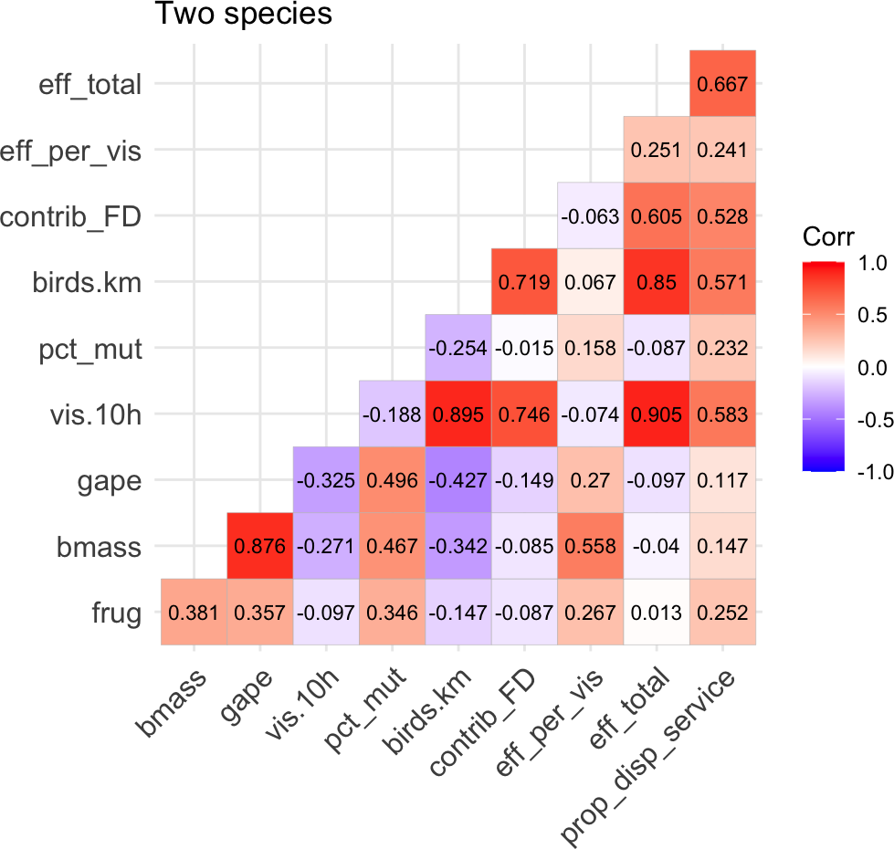

```r
# Two species pooled
 ggcorrplot(corr,
           hc.order = F,
          # p.mat = pmat,
           type = "lower",
           insig = "pch",
           digits= 3,
           lab = TRUE, lab_size= 3) + ggtitle("Two species")
```

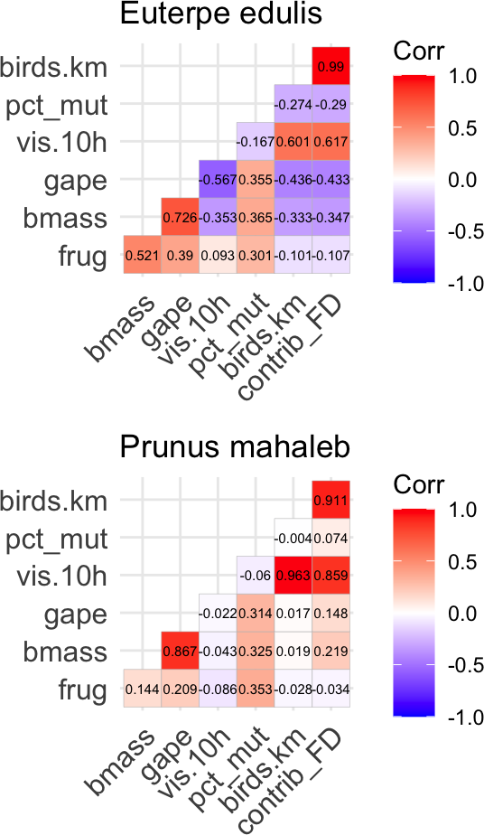

```r
#---------------------------------------------------------------------
# Add correlation coefficients
  theme_set(theme_bw(base_size = 12))
  p1<- ggcorrplot(corr1,
           hc.order = F,
          # p.mat = pmat1,
           type = "lower",
           insig = "pch",
           digits= 3,
           lab = TRUE, lab_size= 2) + ggtitle("Euterpe edulis")
  p2<- ggcorrplot(corr2,
           hc.order = F,
         #  p.mat = pmat2,
           insig = "pch",
           type = "lower",
           digits= 3,
           lab = TRUE, lab_size= 2) + ggtitle("Prunus mahaleb")
  grid.arrange(p1, p2, nrow = 2)
```

### FD and SDE

Here I examine the relationships between FD and seed dispersal effectiveness (SDE).

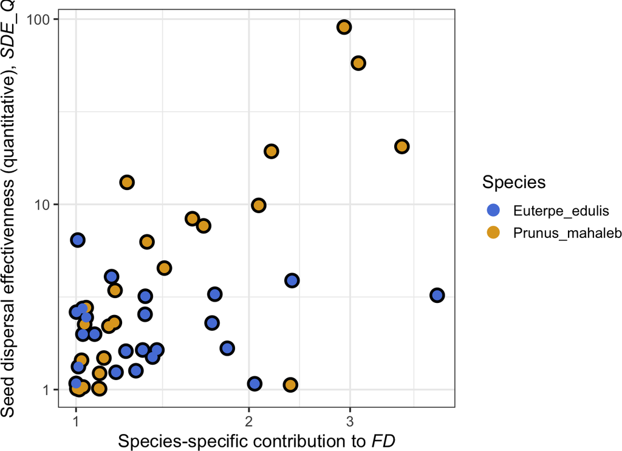

```r
theme_set(theme_bw(base_size = 14))
p1<- ggplot(funct, aes(x= contrib_FD+1, y= eff_total+1, color=plant)) +
            geom_point(size= 4) +
            geom_point(aes(color= plant), size= 5, color= "black") +
#           geom_point(aes(color= plant), size= 5) +
            geom_point(aes(color= plant), size= 3) +
            scale_x_continuous(trans='log10') +
            scale_y_continuous(trans='log10') +
            scale_color_manual(values=c("#5681DC", "#DEA525")) +
            ggplot2::labs(color = "Species") +
            ggplot2::labs(x = TeX(r"(Species-specific contribution to \textit{FD})"),
             y = TeX(r"(Seed dispersal effectivenness (quantitative), \textit{SDE_{Q}})"))
p1
```

```r
# Correlations for two species
cor.test(log(funct$contrib_FD+1),log(funct$eff_total+1))
```

```
    Pearson's product-moment correlation

data:  log(funct$contrib_FD + 1) and log(funct$eff_total + 1)
t = 5.2, df = 47, p-value = 4.2e-06
alternative hypothesis: true correlation is not equal to 0
95 percent confidence interval:
 0.38971 0.75711
sample estimates:
    cor
0.60465
```

```r
# Euterpe edulis
pp<- funct %>%
    dplyr::filter(plant== "Euterpe_edulis")
    cor.test(log(pp$contrib_FD+1),log(pp$eff_total+1))
```

```
    Pearson's product-moment correlation

data:  log(pp$contrib_FD + 1) and log(pp$eff_total + 1)
t = 0.626, df = 21, p-value = 0.54
alternative hypothesis: true correlation is not equal to 0
95 percent confidence interval:
 -0.29331  0.51854
sample estimates:
    cor
0.13525
```

```r
# Prunus mahaleb
pp<- funct %>%
    dplyr::filter(plant== "Prunus_mahaleb")
    cor.test(log(pp$contrib_FD+1),log(pp$eff_total+1))
```

```
    Pearson's product-moment correlation

data:  log(pp$contrib_FD + 1) and log(pp$eff_total + 1)
t = 6.61, df = 24, p-value = 7.8e-07
alternative hypothesis: true correlation is not equal to 0
95 percent confidence interval:
 0.60378 0.90807
sample estimates:
    cor
0.80327
```

# Multilayer analysis

| ## NOTE: |
| --- |
| Code for multilayer analysis with the `muxViz` package is provided in a separate folder. |
| It requires specific installation of external binaries. I’ve run it on `R` version |
| 4.0, since several required packages have not recent versions. |

{{< pagebreak >}}

# `R` packages used

We used R version 4.4.1 [@base] and the following R packages: ade4 v. 1.7.23 [@ade42004c; @ade42007a; @ade42007d; @ade42018b; @ade42018e], ape v. 5.8.1 [@ape], bayestestR v. 0.15.2 [@bayestestR], boot v. 1.3.31 [@boot1997; @boot2024], correlation v. 0.8.7 [@correlationArticle; @correlationPackage], datawizard v. 1.0.1 [@datawizard], devtools v. 2.4.5 [@devtools], easystats v. 0.7.4 [@easystats], effectsize v. 1.0.0 [@effectsize], equatiomatic v. 0.3.6 [@equatiomatic], FD v. 1.0.12.3 [@FD2010; @FD2014], geometry v. 0.5.2 [@geometry], ggcorrplot v. 0.1.4.1 [@ggcorrplot], gridExtra v. 2.3 [@gridExtra], here v. 1.0.1 [@here], insight v. 1.1.0 [@insight], kableExtra v. 1.4.0 [@kableExtra], knitr v. 1.50 [@knitr2014; @knitr2015; @knitr2025], latex2exp v. 0.9.6 [@latex2exp], lattice v. 0.22.6 [@lattice], lme4 v. 1.1.36 [@lme4], Matrix v. 1.7.3 [@Matrix], modelbased v. 0.10.0 [@modelbased], parameters v. 0.24.2 [@parameters], performance v. 0.13.0 [@performance], permute v. 0.9.7 [@permute], report v. 0.6.1 [@report], rmarkdown v. 2.29 [@rmarkdown2018; @rmarkdown2020; @rmarkdown2024], rstatix v. 0.7.2 [@rstatix], see v. 0.11.0 [@see], tidyverse v. 2.0.0 [@tidyverse], usethis v. 3.1.0 [@usethis], vegan v. 2.6.10 [@vegan].

{{< pagebreak >}}

{{< pagebreak >}}